# Final Project

#### 6. Unsupervised Learning: Is there a potentially anomaly?

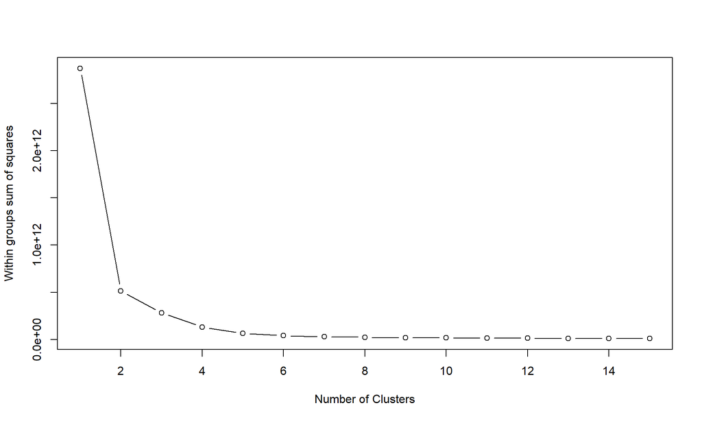

```r
# Establishing number of clusters
  set.seed(579)
  data.atom = as.data.frame(scale(data.anom))
  km.ss = c()
  for (i in 1:15) {
    km.out = kmeans(na.omit(data.anom), i, nstart = 20)
    km.ss  = rbind(km.ss, km.out$tot.withinss)
  }

  plot(1:15, km.ss, type = "b", xlab = "Number of Clusters", ylab = "Within groups sum of squares")
```

```r
# Best cluster k = 4
  k        = 4
  km.out   = kmeans(na.omit(data.anom), k, nstart = 20)
  centroid = km.out$centers

  v.centroid = c()

# Radius: centroid to furthest data point in each cluster
  for(i in 1:k){
    n      = nrow(data.anom[km.out$cluster == i,])
    d.data = data.anom[km.out$cluster == i,]
    d.ref  = centroid[i]
    d.temp = c()
    for(j in 1:n){
      dist   = dist(rbind(d.data[j,],d.ref), method = "euclidian")
      d.temp = rbind(d.temp, dist)
    }
    v.centroid = c(v.centroid,max(d.temp))
  }
  epsilon    = 1.001
  v.centroid = v.centroid*epsilon

# Anomaly Detection function
  anomalyDetection <- function(data){
    anomalyT = c()
    for(j in 1:nrow(data)){
      test = data[j,]
      t.centroid = c()
      for(i in 1:k){
        dist       = dist(rbind(test,centroid[i]), method = "euclidian")
        t.centroid = rbind(t.centroid, dist)
      }
      if((max(v.centroid)-max(t.centroid)) < 0){
        anomalyT = rbind(anomalyT,"Potentially Anomaly")
      } else {
        anomalyT = rbind(anomalyT,"Normal Login")
      }
    }
    summary(anomalyT)
  }

# Testing the anomalyDetection function
# data.anom: all variables should be 100% classfied as 'Normal Login'
  anomalyDetection(data.anom)
```

```
##             V1
##  Normal Login:3000
```

```r
# fake A data: all nearZeroVar variables are transformed
  fakeA = data.anom

  fakeA$land              = sample(c(0,1,1,1),nrow(fakeA),replace = T)
  fakeA$wrong_fragment    = abs(rnorm(nrow(fakeA),80000,150000))
  fakeA$urgent            = abs(rnorm(nrow(fakeA),10000,90000))
  fakeA$num_outbound_cmds = abs(rnorm(nrow(fakeA),1000,22000))
  fakeA$is_host_login     = sample(c(0,1,1,1),nrow(fakeA),replace = T)

  anomalyDetection(fakeA)
```

```
##                    V1
##  Normal Login       :2586
##  Potentially Anomaly: 414
```

```r
# fake B data: change distribution of duration, flag and src_bytes
  fakeB = data.anom

  fakeB$duration  = abs(rnorm(nrow(fakeB),300, 2000))
  fakeB$src_bytes = abs(rnorm(nrow(fakeB),8000,600000))
  fakeB$flag2     = sample(c(1,2,2,2,3,3,4,4,5,5,5,5,6),nrow(fakeB),replace = T)

  anomalyDetection(fakeB)
```

```
##                    V1
##  Normal Login       :1074
##  Potentially Anomaly:1926
```

- **For anomaly detection, we first used an unsupervised learning method to cluster the raw data. We determined the best number of clusters by comparing the within-sum-of-squares metric for different values of k. Using k = 4, we found the centroid for each cluster and the distance from each cluster centroid to the furthest observation within that cluster.**
- **This maximum distance plus a buffer epsilon serve as a threshold for anomaly detection. For each data, our function calculates the distance to each cluster centroid. If this distance is greater than the threshold, the observation is classified as an anomaly.**
- **We tested our fucntion three times: once with our original dataset (as a baseline case to ensure an anomaly detection rate of 0%), once with mutated values for all features with zero variability, and once with mutated values for variable features correlated with the is_intrusion response. For the features with zero variability, it was necessary to change the values by a very large multiplier in order for these observations to be classified as anamolies. For the variable features correlated with the response, we only had to generate new values using a normal distribution with twice the original mean and twice the original standard deviation.**